# Optimal Treatment Analysis

## Outcome Variable

**Outcome Variable:** ever_wasted

## Predictor Variables

**Intervention Variable:** perdiar6

**Adjustment Set:**

- arm
- sex
- W_mage
- meducyrs
- W_mhtcm
- W_mwtkg
- W_mbmi
- W_birthwt
- W_birthlen
- W_nrooms
- month
- brthmon
- impfloor
- impsan
- safeh20
- delta_W_mage
- delta_meducyrs
- delta_W_mhtcm
- delta_W_mwtkg
- delta_W_mbmi
- delta_W_birthwt
- delta_W_birthlen
- delta_W_nrooms
- delta_month
- delta_brthmon
- delta_impfloor
- delta_impsan
- delta_safeh20

## Stratifying Variables

The analysis was stratified on these variable(s):

- agecat
- studyid
- country

## Data Summary

| agecat | studyid | country | perdiar6 | ever_wasted | n_cell | n |
| --- | --- | --- | --- | --- | --- | --- |
| 0-24 months (no birth wast) | ki0047075b-MAL-ED | BANGLADESH | (0%, 5%] | 0 | 75 | 261 |
| 0-24 months (no birth wast) | ki0047075b-MAL-ED | BANGLADESH | (0%, 5%] | 1 | 23 | 261 |
| 0-24 months (no birth wast) | ki0047075b-MAL-ED | BANGLADESH | 0% | 0 | 63 | 261 |
| 0-24 months (no birth wast) | ki0047075b-MAL-ED | BANGLADESH | 0% | 1 | 20 | 261 |
| 0-24 months (no birth wast) | ki0047075b-MAL-ED | BANGLADESH | >5% | 0 | 65 | 261 |
| 0-24 months (no birth wast) | ki0047075b-MAL-ED | BANGLADESH | >5% | 1 | 15 | 261 |
| 0-24 months (no birth wast) | ki0047075b-MAL-ED | BRAZIL | (0%, 5%] | 0 | 14 | 229 |
| 0-24 months (no birth wast) | ki0047075b-MAL-ED | BRAZIL | (0%, 5%] | 1 | 1 | 229 |
| 0-24 months (no birth wast) | ki0047075b-MAL-ED | BRAZIL | 0% | 0 | 202 | 229 |
| 0-24 months (no birth wast) | ki0047075b-MAL-ED | BRAZIL | 0% | 1 | 10 | 229 |
| 0-24 months (no birth wast) | ki0047075b-MAL-ED | BRAZIL | >5% | 0 | 1 | 229 |
| 0-24 months (no birth wast) | ki0047075b-MAL-ED | BRAZIL | >5% | 1 | 1 | 229 |
| 0-24 months (no birth wast) | ki0047075b-MAL-ED | INDIA | (0%, 5%] | 0 | 86 | 242 |
| 0-24 months (no birth wast) | ki0047075b-MAL-ED | INDIA | (0%, 5%] | 1 | 42 | 242 |
| 0-24 months (no birth wast) | ki0047075b-MAL-ED | INDIA | 0% | 0 | 32 | 242 |
| 0-24 months (no birth wast) | ki0047075b-MAL-ED | INDIA | 0% | 1 | 23 | 242 |
| 0-24 months (no birth wast) | ki0047075b-MAL-ED | INDIA | >5% | 0 | 35 | 242 |
| 0-24 months (no birth wast) | ki0047075b-MAL-ED | INDIA | >5% | 1 | 24 | 242 |
| 0-24 months (no birth wast) | ki0047075b-MAL-ED | NEPAL | (0%, 5%] | 0 | 63 | 238 |
| 0-24 months (no birth wast) | ki0047075b-MAL-ED | NEPAL | (0%, 5%] | 1 | 13 | 238 |
| 0-24 months (no birth wast) | ki0047075b-MAL-ED | NEPAL | 0% | 0 | 64 | 238 |
| 0-24 months (no birth wast) | ki0047075b-MAL-ED | NEPAL | 0% | 1 | 18 | 238 |
| 0-24 months (no birth wast) | ki0047075b-MAL-ED | NEPAL | >5% | 0 | 66 | 238 |
| 0-24 months (no birth wast) | ki0047075b-MAL-ED | NEPAL | >5% | 1 | 14 | 238 |
| 0-24 months (no birth wast) | ki0047075b-MAL-ED | PERU | (0%, 5%] | 0 | 88 | 299 |
| 0-24 months (no birth wast) | ki0047075b-MAL-ED | PERU | (0%, 5%] | 1 | 5 | 299 |
| 0-24 months (no birth wast) | ki0047075b-MAL-ED | PERU | 0% | 0 | 80 | 299 |
| 0-24 months (no birth wast) | ki0047075b-MAL-ED | PERU | 0% | 1 | 6 | 299 |
| 0-24 months (no birth wast) | ki0047075b-MAL-ED | PERU | >5% | 0 | 111 | 299 |
| 0-24 months (no birth wast) | ki0047075b-MAL-ED | PERU | >5% | 1 | 9 | 299 |

[output cut: 258 more lines]

The following strata were considered:

- agecat: 0-24 months (no birth wast), studyid: ki0047075b-MAL-ED, country: BANGLADESH
- agecat: 0-24 months (no birth wast), studyid: ki0047075b-MAL-ED, country: BRAZIL
- agecat: 0-24 months (no birth wast), studyid: ki0047075b-MAL-ED, country: INDIA
- agecat: 0-24 months (no birth wast), studyid: ki0047075b-MAL-ED, country: NEPAL
- agecat: 0-24 months (no birth wast), studyid: ki0047075b-MAL-ED, country: PERU
- agecat: 0-24 months (no birth wast), studyid: ki0047075b-MAL-ED, country: SOUTH AFRICA
- agecat: 0-24 months (no birth wast), studyid: ki0047075b-MAL-ED, country: TANZANIA, UNITED REPUBLIC OF
- agecat: 0-24 months (no birth wast), studyid: ki1000109-ResPak, country: PAKISTAN
- agecat: 0-24 months (no birth wast), studyid: ki1017093-NIH-Birth, country: BANGLADESH
- agecat: 0-24 months (no birth wast), studyid: ki1017093b-PROVIDE, country: BANGLADESH
- agecat: 0-24 months (no birth wast), studyid: ki1017093c-NIH-Crypto, country: BANGLADESH
- agecat: 0-24 months (no birth wast), studyid: ki1114097-CMIN, country: BANGLADESH
- agecat: 0-24 months (no birth wast), studyid: ki1114097-CMIN, country: BRAZIL
- agecat: 0-24 months (no birth wast), studyid: ki1114097-CMIN, country: GUINEA-BISSAU
- agecat: 0-24 months (no birth wast), studyid: ki1114097-CMIN, country: PERU
- agecat: 0-24 months (no birth wast), studyid: ki1114097-CONTENT, country: PERU
- agecat: 0-6 months (no birth wast), studyid: ki0047075b-MAL-ED, country: BANGLADESH
- agecat: 0-6 months (no birth wast), studyid: ki0047075b-MAL-ED, country: BRAZIL
- agecat: 0-6 months (no birth wast), studyid: ki0047075b-MAL-ED, country: INDIA
- agecat: 0-6 months (no birth wast), studyid: ki0047075b-MAL-ED, country: NEPAL
- agecat: 0-6 months (no birth wast), studyid: ki0047075b-MAL-ED, country: PERU
- agecat: 0-6 months (no birth wast), studyid: ki0047075b-MAL-ED, country: SOUTH AFRICA
- agecat: 0-6 months (no birth wast), studyid: ki0047075b-MAL-ED, country: TANZANIA, UNITED REPUBLIC OF
- agecat: 0-6 months (no birth wast), studyid: ki1000109-ResPak, country: PAKISTAN
- agecat: 0-6 months (no birth wast), studyid: ki1017093-NIH-Birth, country: BANGLADESH
- agecat: 0-6 months (no birth wast), studyid: ki1017093b-PROVIDE, country: BANGLADESH
- agecat: 0-6 months (no birth wast), studyid: ki1017093c-NIH-Crypto, country: BANGLADESH
- agecat: 0-6 months (no birth wast), studyid: ki1114097-CMIN, country: BANGLADESH
- agecat: 0-6 months (no birth wast), studyid: ki1114097-CMIN, country: BRAZIL
- agecat: 0-6 months (no birth wast), studyid: ki1114097-CMIN, country: GUINEA-BISSAU
- agecat: 0-6 months (no birth wast), studyid: ki1114097-CMIN, country: PERU
- agecat: 0-6 months (no birth wast), studyid: ki1114097-CONTENT, country: PERU
- agecat: 6-24 months, studyid: ki0047075b-MAL-ED, country: BANGLADESH
- agecat: 6-24 months, studyid: ki0047075b-MAL-ED, country: BRAZIL
- agecat: 6-24 months, studyid: ki0047075b-MAL-ED, country: INDIA
- agecat: 6-24 months, studyid: ki0047075b-MAL-ED, country: NEPAL
- agecat: 6-24 months, studyid: ki0047075b-MAL-ED, country: PERU
- agecat: 6-24 months, studyid: ki0047075b-MAL-ED, country: SOUTH AFRICA
- agecat: 6-24 months, studyid: ki0047075b-MAL-ED, country: TANZANIA, UNITED REPUBLIC OF
- agecat: 6-24 months, studyid: ki1000109-ResPak, country: PAKISTAN
- agecat: 6-24 months, studyid: ki1017093-NIH-Birth, country: BANGLADESH
- agecat: 6-24 months, studyid: ki1017093b-PROVIDE, country: BANGLADESH
- agecat: 6-24 months, studyid: ki1017093c-NIH-Crypto, country: BANGLADESH
- agecat: 6-24 months, studyid: ki1114097-CMIN, country: BANGLADESH
- agecat: 6-24 months, studyid: ki1114097-CMIN, country: BRAZIL
- agecat: 6-24 months, studyid: ki1114097-CMIN, country: GUINEA-BISSAU
- agecat: 6-24 months, studyid: ki1114097-CMIN, country: PERU
- agecat: 6-24 months, studyid: ki1114097-CONTENT, country: PERU

### Dropped Strata

Some strata were dropped due to rare outcomes:

- agecat: 0-24 months (no birth wast), studyid: ki0047075b-MAL-ED, country: BRAZIL
- agecat: 0-24 months (no birth wast), studyid: ki0047075b-MAL-ED, country: SOUTH AFRICA
- agecat: 0-24 months (no birth wast), studyid: ki0047075b-MAL-ED, country: TANZANIA, UNITED REPUBLIC OF
- agecat: 0-24 months (no birth wast), studyid: ki1114097-CMIN, country: BRAZIL
- agecat: 0-24 months (no birth wast), studyid: ki1114097-CONTENT, country: PERU
- agecat: 0-6 months (no birth wast), studyid: ki0047075b-MAL-ED, country: BRAZIL
- agecat: 0-6 months (no birth wast), studyid: ki0047075b-MAL-ED, country: NEPAL
- agecat: 0-6 months (no birth wast), studyid: ki0047075b-MAL-ED, country: PERU
- agecat: 0-6 months (no birth wast), studyid: ki0047075b-MAL-ED, country: SOUTH AFRICA
- agecat: 0-6 months (no birth wast), studyid: ki0047075b-MAL-ED, country: TANZANIA, UNITED REPUBLIC OF
- agecat: 0-6 months (no birth wast), studyid: ki1114097-CMIN, country: BRAZIL
- agecat: 0-6 months (no birth wast), studyid: ki1114097-CMIN, country: GUINEA-BISSAU
- agecat: 0-6 months (no birth wast), studyid: ki1114097-CMIN, country: PERU
- agecat: 0-6 months (no birth wast), studyid: ki1114097-CONTENT, country: PERU
- agecat: 6-24 months, studyid: ki0047075b-MAL-ED, country: BRAZIL
- agecat: 6-24 months, studyid: ki0047075b-MAL-ED, country: PERU
- agecat: 6-24 months, studyid: ki0047075b-MAL-ED, country: SOUTH AFRICA
- agecat: 6-24 months, studyid: ki0047075b-MAL-ED, country: TANZANIA, UNITED REPUBLIC OF
- agecat: 6-24 months, studyid: ki1114097-CMIN, country: BRAZIL
- agecat: 6-24 months, studyid: ki1114097-CONTENT, country: PERU

## Methods Detail

We’re interested in the causal parameters $E[Y_a]$ for all values of $a \in \mathcal{A}$. These parameters represent the mean outcome if, possibly contrary to fact, we intervened to set all units to have $A=a$. Under the randomization and positivity assumptions, these are identified by the statistical parameters $\psi_a=E_W[E_{Y|A,W}(Y|A=a,W)]$. In addition, we’re interested in the mean of $Y$, $E[Y]$ under no intervention (the observed mean). We will estimate these parameters by using SuperLearner to fit the relevant likelihood factors – $E_{Y|A,W}(Y|A=a,W)$ and $p(A=a|W)$, and then updating our likelihood fit using a joint TMLE.

For unadjusted analyses ($W=\{\}$), initial likelihoods were estimated using Lrnr_glm to estimate the simple $E(Y|A)$ and Lrnr_mean to estimate $p(A)$. For adjusted analyses, a small library containing Lrnr_glmnet, Lrnr_xgboost, and Lrnr_mean was used.

Having estimated these parameters, we will then use the delta method to estimate relative risks and attributable risks relative to a prespecified baseline level of $A$.

# Results Detail

## Results Plots

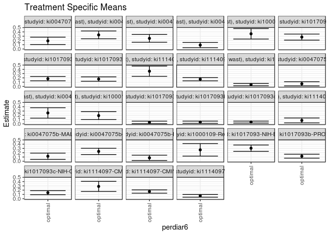

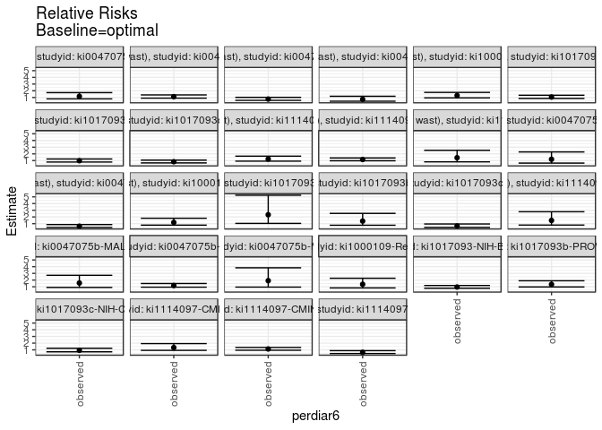

## Results Table

### Parameter: TSM

| agecat | studyid | country | intervention_level | baseline_level | estimate | ci_lower | ci_upper |
| --- | --- | --- | --- | --- | --- | --- | --- |
| 0-24 months (no birth wast) | ki0047075b-MAL-ED | BANGLADESH | optimal | NA | 0.1903881 | 0.1032799 | 0.2774962 |
| 0-24 months (no birth wast) | ki0047075b-MAL-ED | INDIA | optimal | NA | 0.3299642 | 0.2383349 | 0.4215935 |
| 0-24 months (no birth wast) | ki0047075b-MAL-ED | NEPAL | optimal | NA | 0.2491665 | 0.1577825 | 0.3405506 |
| 0-24 months (no birth wast) | ki0047075b-MAL-ED | PERU | optimal | NA | 0.0923044 | 0.0303859 | 0.1542230 |
| 0-24 months (no birth wast) | ki1000109-ResPak | PAKISTAN | optimal | NA | 0.3558790 | 0.2336866 | 0.4780713 |
| 0-24 months (no birth wast) | ki1017093-NIH-Birth | BANGLADESH | optimal | NA | 0.2788930 | 0.2079383 | 0.3498477 |
| 0-24 months (no birth wast) | ki1017093b-PROVIDE | BANGLADESH | optimal | NA | 0.1809547 | 0.1309659 | 0.2309436 |
| 0-24 months (no birth wast) | ki1017093c-NIH-Crypto | BANGLADESH | optimal | NA | 0.1722665 | 0.1208726 | 0.2236604 |
| 0-24 months (no birth wast) | ki1114097-CMIN | BANGLADESH | optimal | NA | 0.3558045 | 0.2354722 | 0.4761369 |
| 0-24 months (no birth wast) | ki1114097-CMIN | GUINEA-BISSAU | optimal | NA | 0.1683513 | 0.1301283 | 0.2065744 |
| 0-24 months (no birth wast) | ki1114097-CMIN | PERU | optimal | NA | 0.0421780 | 0.0148812 | 0.0694747 |
| 0-6 months (no birth wast) | ki0047075b-MAL-ED | BANGLADESH | optimal | NA | 0.0613457 | 0.0127955 | 0.1098960 |
| 0-6 months (no birth wast) | ki0047075b-MAL-ED | INDIA | optimal | NA | 0.2548805 | 0.1326429 | 0.3771182 |
| 0-6 months (no birth wast) | ki1000109-ResPak | PAKISTAN | optimal | NA | 0.1931760 | 0.0997909 | 0.2865612 |
| 0-6 months (no birth wast) | ki1017093-NIH-Birth | BANGLADESH | optimal | NA | 0.0340901 | 0.0047473 | 0.0634330 |
| 0-6 months (no birth wast) | ki1017093b-PROVIDE | BANGLADESH | optimal | NA | 0.0379685 | 0.0120096 | 0.0639275 |
| 0-6 months (no birth wast) | ki1017093c-NIH-Crypto | BANGLADESH | optimal | NA | 0.0408709 | 0.0177931 | 0.0639486 |
| 0-6 months (no birth wast) | ki1114097-CMIN | BANGLADESH | optimal | NA | 0.0797816 | 0.0225719 | 0.1369913 |
| 6-24 months | ki0047075b-MAL-ED | BANGLADESH | optimal | NA | 0.1176797 | 0.0440871 | 0.1912722 |
| 6-24 months | ki0047075b-MAL-ED | INDIA | optimal | NA | 0.2310350 | 0.1570281 | 0.3050419 |
| 6-24 months | ki0047075b-MAL-ED | NEPAL | optimal | NA | 0.0803751 | 0.0184095 | 0.1423407 |
| 6-24 months | ki1000109-ResPak | PAKISTAN | optimal | NA | 0.2669613 | 0.1210505 | 0.4128720 |
| 6-24 months | ki1017093-NIH-Birth | BANGLADESH | optimal | NA | 0.3053730 | 0.2306679 | 0.3800782 |
| 6-24 months | ki1017093b-PROVIDE | BANGLADESH | optimal | NA | 0.1190541 | 0.0728579 | 0.1652503 |
| 6-24 months | ki1017093c-NIH-Crypto | BANGLADESH | optimal | NA | 0.1408164 | 0.0934262 | 0.1882066 |
| 6-24 months | ki1114097-CMIN | BANGLADESH | optimal | NA | 0.2876719 | 0.1695465 | 0.4057974 |
| 6-24 months | ki1114097-CMIN | GUINEA-BISSAU | optimal | NA | 0.1675709 | 0.1287712 | 0.2063707 |
| 6-24 months | ki1114097-CMIN | PERU | optimal | NA | 0.0667779 | 0.0355606 | 0.0979951 |

### Parameter: E(Y)

| agecat | studyid | country | intervention_level | baseline_level | estimate | ci_lower | ci_upper |
| --- | --- | --- | --- | --- | --- | --- | --- |
| 0-24 months (no birth wast) | ki0047075b-MAL-ED | BANGLADESH | observed | NA | 0.2222222 | 0.1716883 | 0.2727561 |
| 0-24 months (no birth wast) | ki0047075b-MAL-ED | INDIA | observed | NA | 0.3677686 | 0.3068900 | 0.4286472 |
| 0-24 months (no birth wast) | ki0047075b-MAL-ED | NEPAL | observed | NA | 0.1890756 | 0.1392237 | 0.2389275 |
| 0-24 months (no birth wast) | ki0047075b-MAL-ED | PERU | observed | NA | 0.0668896 | 0.0385244 | 0.0952548 |
| 0-24 months (no birth wast) | ki1000109-ResPak | PAKISTAN | observed | NA | 0.4578755 | 0.3986666 | 0.5170843 |
| 0-24 months (no birth wast) | ki1017093-NIH-Birth | BANGLADESH | observed | NA | 0.2981575 | 0.2614320 | 0.3348829 |
| 0-24 months (no birth wast) | ki1017093b-PROVIDE | BANGLADESH | observed | NA | 0.1775837 | 0.1489858 | 0.2061816 |
| 0-24 months (no birth wast) | ki1017093c-NIH-Crypto | BANGLADESH | observed | NA | 0.1432361 | 0.1182149 | 0.1682572 |
| 0-24 months (no birth wast) | ki1114097-CMIN | BANGLADESH | observed | NA | 0.4372624 | 0.3771974 | 0.4973274 |
| 0-24 months (no birth wast) | ki1114097-CMIN | GUINEA-BISSAU | observed | NA | 0.1951754 | 0.1694388 | 0.2209121 |
| 0-24 months (no birth wast) | ki1114097-CMIN | PERU | observed | NA | 0.0600559 | 0.0426409 | 0.0774709 |
| 0-6 months (no birth wast) | ki0047075b-MAL-ED | BANGLADESH | observed | NA | 0.0730769 | 0.0413805 | 0.1047733 |
| 0-6 months (no birth wast) | ki0047075b-MAL-ED | INDIA | observed | NA | 0.1576764 | 0.1115695 | 0.2037832 |
| 0-6 months (no birth wast) | ki1000109-ResPak | PAKISTAN | observed | NA | 0.2287823 | 0.1786790 | 0.2788855 |
| 0-6 months (no birth wast) | ki1017093-NIH-Birth | BANGLADESH | observed | NA | 0.0794473 | 0.0574004 | 0.1014943 |
| 0-6 months (no birth wast) | ki1017093b-PROVIDE | BANGLADESH | observed | NA | 0.0527086 | 0.0359384 | 0.0694789 |
| 0-6 months (no birth wast) | ki1017093c-NIH-Crypto | BANGLADESH | observed | NA | 0.0267023 | 0.0151493 | 0.0382553 |
| 0-6 months (no birth wast) | ki1114097-CMIN | BANGLADESH | observed | NA | 0.1183206 | 0.0791362 | 0.1575050 |
| 6-24 months | ki0047075b-MAL-ED | BANGLADESH | observed | NA | 0.1833333 | 0.1342773 | 0.2323893 |
| 6-24 months | ki0047075b-MAL-ED | INDIA | observed | NA | 0.2723404 | 0.2153029 | 0.3293779 |
| 6-24 months | ki0047075b-MAL-ED | NEPAL | observed | NA | 0.1531915 | 0.1070438 | 0.1993392 |
| 6-24 months | ki1000109-ResPak | PAKISTAN | observed | NA | 0.3652174 | 0.3028556 | 0.4275792 |
| 6-24 months | ki1017093-NIH-Birth | BANGLADESH | observed | NA | 0.2939002 | 0.2554778 | 0.3323226 |
| 6-24 months | ki1017093b-PROVIDE | BANGLADESH | observed | NA | 0.1609756 | 0.1319065 | 0.1900447 |
| 6-24 months | ki1017093c-NIH-Crypto | BANGLADESH | observed | NA | 0.1315068 | 0.1069744 | 0.1560393 |
| 6-24 months | ki1114097-CMIN | BANGLADESH | observed | NA | 0.3849206 | 0.3247254 | 0.4451159 |
| 6-24 months | ki1114097-CMIN | GUINEA-BISSAU | observed | NA | 0.1896745 | 0.1639180 | 0.2154311 |
| 6-24 months | ki1114097-CMIN | PERU | observed | NA | 0.0420420 | 0.0267891 | 0.0572949 |

### Parameter: RR

| agecat | studyid | country | intervention_level | baseline_level | estimate | ci_lower | ci_upper |
| --- | --- | --- | --- | --- | --- | --- | --- |
| 0-24 months (no birth wast) | ki0047075b-MAL-ED | BANGLADESH | observed | optimal | 1.1672065 | 0.7904819 | 1.7234691 |
| 0-24 months (no birth wast) | ki0047075b-MAL-ED | INDIA | observed | optimal | 1.1145713 | 0.9007564 | 1.3791401 |
| 0-24 months (no birth wast) | ki0047075b-MAL-ED | NEPAL | observed | optimal | 0.7588324 | 0.5649323 | 1.0192844 |
| 0-24 months (no birth wast) | ki0047075b-MAL-ED | PERU | observed | optimal | 0.7246634 | 0.4451221 | 1.1797595 |
| 0-24 months (no birth wast) | ki1000109-ResPak | PAKISTAN | observed | optimal | 1.2866045 | 0.9433225 | 1.7548092 |
| 0-24 months (no birth wast) | ki1017093-NIH-Birth | BANGLADESH | observed | optimal | 1.0690747 | 0.8589845 | 1.3305487 |
| 0-24 months (no birth wast) | ki1017093b-PROVIDE | BANGLADESH | observed | optimal | 0.9813709 | 0.7795161 | 1.2354957 |
| 0-24 months (no birth wast) | ki1017093c-NIH-Crypto | BANGLADESH | observed | optimal | 0.8314794 | 0.6476606 | 1.0674697 |
| 0-24 months (no birth wast) | ki1114097-CMIN | BANGLADESH | observed | optimal | 1.2289398 | 0.9106999 | 1.6583871 |
| 0-24 months (no birth wast) | ki1114097-CMIN | GUINEA-BISSAU | observed | optimal | 1.1593341 | 0.9675283 | 1.3891642 |
| 0-24 months (no birth wast) | ki1114097-CMIN | PERU | observed | optimal | 1.4238673 | 0.8017655 | 2.5286672 |
| 0-6 months (no birth wast) | ki0047075b-MAL-ED | BANGLADESH | observed | optimal | 1.1912305 | 0.6198972 | 2.2891381 |
| 0-6 months (no birth wast) | ki0047075b-MAL-ED | INDIA | observed | optimal | 0.6186285 | 0.4453638 | 0.8593002 |
| 0-6 months (no birth wast) | ki1000109-ResPak | PAKISTAN | observed | optimal | 1.1843203 | 0.7755997 | 1.8084259 |
| 0-6 months (no birth wast) | ki1017093-NIH-Birth | BANGLADESH | observed | optimal | 2.3305075 | 1.0363805 | 5.2406095 |
| 0-6 months (no birth wast) | ki1017093b-PROVIDE | BANGLADESH | observed | optimal | 1.3882189 | 0.7604938 | 2.5340793 |
| 0-6 months (no birth wast) | ki1017093c-NIH-Crypto | BANGLADESH | observed | optimal | 0.6533328 | 0.4482479 | 0.9522493 |
| 0-6 months (no birth wast) | ki1114097-CMIN | BANGLADESH | observed | optimal | 1.4830558 | 0.7920844 | 2.7767929 |
| 6-24 months | ki0047075b-MAL-ED | BANGLADESH | observed | optimal | 1.5579015 | 0.8960050 | 2.7087538 |
| 6-24 months | ki0047075b-MAL-ED | INDIA | observed | optimal | 1.1787843 | 0.9354116 | 1.4854771 |
| 6-24 months | ki0047075b-MAL-ED | NEPAL | observed | optimal | 1.9059575 | 0.9481249 | 3.8314295 |
| 6-24 months | ki1000109-ResPak | PAKISTAN | observed | optimal | 1.3680538 | 0.8241361 | 2.2709491 |
| 6-24 months | ki1017093-NIH-Birth | BANGLADESH | observed | optimal | 0.9624300 | 0.7822451 | 1.1841193 |
| 6-24 months | ki1017093b-PROVIDE | BANGLADESH | observed | optimal | 1.3521218 | 0.9679509 | 1.8887666 |
| 6-24 months | ki1017093c-NIH-Crypto | BANGLADESH | observed | optimal | 0.9338890 | 0.7033045 | 1.2400726 |
| 6-24 months | ki1114097-CMIN | BANGLADESH | observed | optimal | 1.3380543 | 0.9259867 | 1.9334936 |
| 6-24 months | ki1114097-CMIN | GUINEA-BISSAU | observed | optimal | 1.1319058 | 0.9419734 | 1.3601349 |
| 6-24 months | ki1114097-CMIN | PERU | observed | optimal | 0.6295805 | 0.4526033 | 0.8757593 |

### Parameter: PAR

| agecat | studyid | country | intervention_level | baseline_level | estimate | ci_lower | ci_upper |
| --- | --- | --- | --- | --- | --- | --- | --- |
| 0-24 months (no birth wast) | ki0047075b-MAL-ED | BANGLADESH | optimal | NA | 0.0318341 | -0.0424839 | 0.1061521 |
| 0-24 months (no birth wast) | ki0047075b-MAL-ED | INDIA | optimal | NA | 0.0378044 | -0.0323674 | 0.1079763 |
| 0-24 months (no birth wast) | ki0047075b-MAL-ED | NEPAL | optimal | NA | -0.0600909 | -0.1330711 | 0.0128894 |
| 0-24 months (no birth wast) | ki0047075b-MAL-ED | PERU | optimal | NA | -0.0254148 | -0.0724935 | 0.0216639 |
| 0-24 months (no birth wast) | ki1000109-ResPak | PAKISTAN | optimal | NA | 0.1019965 | -0.0084422 | 0.2124352 |
| 0-24 months (no birth wast) | ki1017093-NIH-Birth | BANGLADESH | optimal | NA | 0.0192645 | -0.0417288 | 0.0802577 |
| 0-24 months (no birth wast) | ki1017093b-PROVIDE | BANGLADESH | optimal | NA | -0.0033710 | -0.0450249 | 0.0382829 |
| 0-24 months (no birth wast) | ki1017093c-NIH-Crypto | BANGLADESH | optimal | NA | -0.0290305 | -0.0721400 | 0.0140791 |
| 0-24 months (no birth wast) | ki1114097-CMIN | BANGLADESH | optimal | NA | 0.0814578 | -0.0249879 | 0.1879036 |
| 0-24 months (no birth wast) | ki1114097-CMIN | GUINEA-BISSAU | optimal | NA | 0.0268241 | -0.0037210 | 0.0573692 |
| 0-24 months (no birth wast) | ki1114097-CMIN | PERU | optimal | NA | 0.0178779 | -0.0068192 | 0.0425750 |
| 0-6 months (no birth wast) | ki0047075b-MAL-ED | BANGLADESH | optimal | NA | 0.0117312 | -0.0285578 | 0.0520202 |
| 0-6 months (no birth wast) | ki0047075b-MAL-ED | INDIA | optimal | NA | -0.0972042 | -0.1906268 | -0.0037816 |
| 0-6 months (no birth wast) | ki1000109-ResPak | PAKISTAN | optimal | NA | 0.0356063 | -0.0462586 | 0.1174711 |
| 0-6 months (no birth wast) | ki1017093-NIH-Birth | BANGLADESH | optimal | NA | 0.0453572 | 0.0151838 | 0.0755306 |
| 0-6 months (no birth wast) | ki1017093b-PROVIDE | BANGLADESH | optimal | NA | 0.0147401 | -0.0085376 | 0.0380178 |
| 0-6 months (no birth wast) | ki1017093c-NIH-Crypto | BANGLADESH | optimal | NA | -0.0141686 | -0.0305608 | 0.0022237 |
| 0-6 months (no birth wast) | ki1114097-CMIN | BANGLADESH | optimal | NA | 0.0385390 | -0.0127682 | 0.0898462 |
| 6-24 months | ki0047075b-MAL-ED | BANGLADESH | optimal | NA | 0.0656537 | -0.0009912 | 0.1322985 |
| 6-24 months | ki0047075b-MAL-ED | INDIA | optimal | NA | 0.0413054 | -0.0123512 | 0.0949621 |
| 6-24 months | ki0047075b-MAL-ED | NEPAL | optimal | NA | 0.0728164 | 0.0133452 | 0.1322876 |
| 6-24 months | ki1000109-ResPak | PAKISTAN | optimal | NA | 0.0982561 | -0.0368495 | 0.2333617 |
| 6-24 months | ki1017093-NIH-Birth | BANGLADESH | optimal | NA | -0.0114729 | -0.0747864 | 0.0518407 |
| 6-24 months | ki1017093b-PROVIDE | BANGLADESH | optimal | NA | 0.0419215 | 0.0018000 | 0.0820431 |
| 6-24 months | ki1017093c-NIH-Crypto | BANGLADESH | optimal | NA | -0.0093095 | -0.0492462 | 0.0306272 |
| 6-24 months | ki1114097-CMIN | BANGLADESH | optimal | NA | 0.0972487 | -0.0085961 | 0.2030935 |
| 6-24 months | ki1114097-CMIN | GUINEA-BISSAU | optimal | NA | 0.0221036 | -0.0087361 | 0.0529432 |
| 6-24 months | ki1114097-CMIN | PERU | optimal | NA | -0.0247358 | -0.0477554 | -0.0017162 |

### Parameter: PAF

| agecat | studyid | country | intervention_level | baseline_level | estimate | ci_lower | ci_upper |
| --- | --- | --- | --- | --- | --- | --- | --- |
| 0-24 months (no birth wast) | ki0047075b-MAL-ED | BANGLADESH | optimal | NA | 0.1432536 | -0.2650511 | 0.4197749 |
| 0-24 months (no birth wast) | ki0047075b-MAL-ED | INDIA | optimal | NA | 0.1027941 | -0.1101781 | 0.2749105 |
| 0-24 months (no birth wast) | ki0047075b-MAL-ED | NEPAL | optimal | NA | -0.3178140 | -0.7701237 | 0.0189195 |
| 0-24 months (no birth wast) | ki0047075b-MAL-ED | PERU | optimal | NA | -0.3799511 | -1.2465747 | 0.1523696 |
| 0-24 months (no birth wast) | ki1000109-ResPak | PAKISTAN | optimal | NA | 0.2227603 | -0.0600828 | 0.4301375 |
| 0-24 months (no birth wast) | ki1017093-NIH-Birth | BANGLADESH | optimal | NA | 0.0646117 | -0.1641653 | 0.2484304 |
| 0-24 months (no birth wast) | ki1017093b-PROVIDE | BANGLADESH | optimal | NA | -0.0189828 | -0.2828471 | 0.1906082 |
| 0-24 months (no birth wast) | ki1017093c-NIH-Crypto | BANGLADESH | optimal | NA | -0.2026756 | -0.5440185 | 0.0632052 |
| 0-24 months (no birth wast) | ki1114097-CMIN | BANGLADESH | optimal | NA | 0.1862905 | -0.0980566 | 0.3970045 |
| 0-24 months (no birth wast) | ki1114097-CMIN | GUINEA-BISSAU | optimal | NA | 0.1374359 | -0.0335615 | 0.2801427 |
| 0-24 months (no birth wast) | ki1114097-CMIN | PERU | optimal | NA | 0.2976874 | -0.2472474 | 0.6045347 |
| 0-6 months (no birth wast) | ki0047075b-MAL-ED | BANGLADESH | optimal | NA | 0.1605319 | -0.6131708 | 0.5631544 |
| 0-6 months (no birth wast) | ki0047075b-MAL-ED | INDIA | optimal | NA | -0.6164791 | -1.2453555 | -0.1637377 |
| 0-6 months (no birth wast) | ki1000109-ResPak | PAKISTAN | optimal | NA | 0.1556338 | -0.2893250 | 0.4470329 |
| 0-6 months (no birth wast) | ki1017093-NIH-Birth | BANGLADESH | optimal | NA | 0.5709089 | 0.0351034 | 0.8091825 |
| 0-6 months (no birth wast) | ki1017093b-PROVIDE | BANGLADESH | optimal | NA | 0.2796525 | -0.3149350 | 0.6053794 |
| 0-6 months (no birth wast) | ki1017093c-NIH-Crypto | BANGLADESH | optimal | NA | -0.5306135 | -1.2309083 | -0.0501452 |
| 0-6 months (no birth wast) | ki1114097-CMIN | BANGLADESH | optimal | NA | 0.3257165 | -0.2624917 | 0.6398723 |
| 6-24 months | ki0047075b-MAL-ED | BANGLADESH | optimal | NA | 0.3581109 | -0.1160652 | 0.6308265 |
| 6-24 months | ki0047075b-MAL-ED | INDIA | optimal | NA | 0.1516684 | -0.0690481 | 0.3268156 |
| 6-24 months | ki0047075b-MAL-ED | NEPAL | optimal | NA | 0.4753293 | -0.0547133 | 0.7390008 |
| 6-24 months | ki1000109-ResPak | PAKISTAN | optimal | NA | 0.2690346 | -0.2133918 | 0.5596555 |
| 6-24 months | ki1017093-NIH-Birth | BANGLADESH | optimal | NA | -0.0390366 | -0.2783716 | 0.1554905 |
| 6-24 months | ki1017093b-PROVIDE | BANGLADESH | optimal | NA | 0.2604217 | -0.0331102 | 0.4705540 |
| 6-24 months | ki1017093c-NIH-Crypto | BANGLADESH | optimal | NA | -0.0707911 | -0.4218593 | 0.1935956 |
| 6-24 months | ki1114097-CMIN | BANGLADESH | optimal | NA | 0.2526462 | -0.0799292 | 0.4828015 |
| 6-24 months | ki1114097-CMIN | GUINEA-BISSAU | optimal | NA | 0.1165343 | -0.0616011 | 0.2647788 |
| 6-24 months | ki1114097-CMIN | PERU | optimal | NA | -0.5883594 | -1.2094404 | -0.1418663 |